# Feature Engineering

All machine learning algorithms use some input data to create outputs. This input data comprise features, which are usually in the form of structured columns. Algorithms require features with some specific characteristic to work properly. Here, the need for feature engineering arises.

Feature engineering is an essential part of building any Machine Learning or Deep Learning model. According to a survey in Forbes, data scientists spending close to 80% of their time in engineering features which is a difficult and time-consuming process, requiring both domain knowledge and mathematical computations.

Feature engineering efforts mainly have two goals:

- Preparing the proper input dataset, compatible with the machine learning algorithm requirements.
- Improving the overall performance of machine learning models.

Considering a dataset, each observation is depicted by a row and each feature by a column. Typically machine learning algorithms work with these numeric matrices and hence most feature engineering techniques deal with converting raw data into some numeric representations which can be easily understood by these algorithms.

Lets see some of the many feature engineering tools which are broadly used in Machine Learning.

## 1) Imputation : Handling Missing Data

Missing values are one of the most common problems you can encounter when you try to prepare your data for machine learning. Whatever is the reason, missing values affect the performance of the machine learning models. Generally you don't want to have any missing data in your data set for the simple reason that it can cause some errors when training your machinery model and therefore you must handle them.

Some machine learning platforms automatically drop the rows which include missing values in the model training phase and it decreases the model performance because of the reduced training size. On the other hand, most of the algorithms do not accept datasets with missing values and gives an error.

The most simple solution to the missing values is to drop the rows or the entire column. And this actually works if you have a large dataset and you know if you have only 1% missing data you know removing 1% of the observations won't change much the learning quality of your model.

So 1% is fine but sometimes you can have a lot of missing data and therefore you must handle them.

Another way is you replace the missing value by the average of all the values in the column in which the data is missing. This is called *imputation*. Imputation is a more preferable option rather than dropping because it preserves the data size.

Missing values might be replaced with 0 as long as you think it is a sensible solution. The best imputation way is to use the average (Mean or Median) of the column. In a case of Categorical Imputation, replacing the missing values with the maximum occurred value in a column is a good option.

Reference: https://scikit-learn.org/stable/modules/generated/sklearn.impute.SimpleImputer.html

Scikit-Learn provides a handy class to take care of missing values: `SimpleImputer`. Here is how to use it.

```python
# importing libraries
import pandas as pd
import numpy as np

#Importing the dataset
dataset = pd.read_csv('Data.csv')
```

```python
dataset
```

|  | Country | Age | Salary | Purchased |
| --- | --- | --- | --- | --- |
| 0 | France | 44.0 | 72000.0 | No |
| 1 | Spain | 27.0 | 48000.0 | Yes |
| 2 | Germany | 30.0 | 54000.0 | No |
| 3 | Spain | 38.0 | 61000.0 | No |
| 4 | Germany | 40.0 | NaN | Yes |
| 5 | France | 35.0 | 58000.0 | Yes |
| 6 | Spain | NaN | 52000.0 | No |
| 7 | France | 48.0 | 79000.0 | Yes |
| 8 | Germany | 50.0 | 83000.0 | No |
| 9 | France | 37.0 | 67000.0 | Yes |

```python
X = dataset.iloc[:, :-1].values
y = dataset.iloc[:, -1].values
```

```python
print(X)
```

```
[['France' 44.0 72000.0]
 ['Spain' 27.0 48000.0]
 ['Germany' 30.0 54000.0]
 ['Spain' 38.0 61000.0]
 ['Germany' 40.0 nan]
 ['France' 35.0 58000.0]
 ['Spain' nan 52000.0]
 ['France' 48.0 79000.0]
 ['Germany' 50.0 83000.0]
 ['France' 37.0 67000.0]]
```

First, you need to create a `SimpleImputer` instance, specifying that you want to replace each attribute’s missing values with the mean of that attribute:

```python
from sklearn.impute import SimpleImputer
imputer = SimpleImputer(missing_values=np.nan, strategy='mean')
```

Now you can fit the imputer instance to the data using the `fit()` method

```python
imputer.fit(X[:, 1:3])
```

```
SimpleImputer()
```

```python
imputer.statistics_
```

```
array([3.87777778e+01, 6.37777778e+04])
```

Now you can use this taught imputer to transform the training set by replacing missing values by the learned mean:

```python
X[:, 1:3] = imputer.transform(X[:, 1:3])
```

```python
print(X)
```

```
[['France' 44.0 72000.0]
 ['Spain' 27.0 48000.0]
 ['Germany' 30.0 54000.0]
 ['Spain' 38.0 61000.0]
 ['Germany' 40.0 63777.77777777778]
 ['France' 35.0 58000.0]
 ['Spain' 38.77777777777778 52000.0]
 ['France' 48.0 79000.0]
 ['Germany' 50.0 83000.0]
 ['France' 37.0 67000.0]]
```

**WARNING:** In new version 0.20 of sklearn, SimpleImputer replaces the previous sklearn.preprocessing.Imputer estimator which is now removed.

## 2) Categorical Encoding

### One-Hot Encoding :

Typically any standard workflow in feature engineering involves some form of transformation of categorical values into numeric labels and then applying some encoding scheme on these values.

And as we can see this dataset contains `Country` column with categories France Spain or Germany. First you might guess that to turn these strings or categories into numbers, one idea would be to encode France into 0 Spain into 1 and Germany into 2. However if we do this our machine learning model would understand that, because France is 0 Spain is 1 and Germany's 2 there is an numerical order between these three countries and mostly it could interpret that. Whereas it is absolutely not the case. There is not a relationship order between these three countries France Germany and Spain. So we want to avoid the model to have such an interpretation because that could cause some misinterpreted correlations between the features and the outcome which we want to predict.

To fix this issue, a common solution is to create one binary attribute per category: one attribute equal to 1 when the category is “France” (and 0 otherwise), another attribute equal to 1 when the category is “Spain (and 0 otherwise), and so on. This is called **one-hot encoding**, *because only one attribute will be equal to 1 (hot), while the others will be 0 (cold)*.

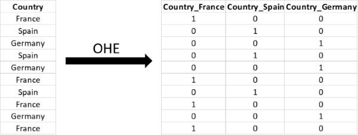

One-hot encoding is one of the most common encoding methods in machine learning. This method spreads the values in a column to multiple flag columns and assigns 0 or 1 to them. This method changes your categorical data, which is challenging to understand for algorithms, to a numerical format and enables you to group your categorical data without losing any information.

The new attributes are sometimes called dummy attributes. Scikit-Learn provides a OneHotEncoder class to convert categorical values into one-hot vectors.

```python
from sklearn.compose import ColumnTransformer
from sklearn.preprocessing import OneHotEncoder

ct = ColumnTransformer(transformers=[('encoder', OneHotEncoder(), [0])], remainder='passthrough')
X = np.array(ct.fit_transform(X))
```

For more info about `ColumnTransformer`: https://scikit-learn.org/stable/modules/generated/sklearn.compose.ColumnTransformer.html

```python
print(X)
```

```
[[1.0 0.0 0.0 44.0 72000.0]
 [0.0 0.0 1.0 27.0 48000.0]
 [0.0 1.0 0.0 30.0 54000.0]
 [0.0 0.0 1.0 38.0 61000.0]
 [0.0 1.0 0.0 40.0 63777.77777777778]
 [1.0 0.0 0.0 35.0 58000.0]
 [0.0 0.0 1.0 38.77777777777778 52000.0]
 [1.0 0.0 0.0 48.0 79000.0]
 [0.0 1.0 0.0 50.0 83000.0]
 [1.0 0.0 0.0 37.0 67000.0]]
```

### Label Encoding

```python
from sklearn.preprocessing import LabelEncoder
le = LabelEncoder()
y = le.fit_transform(y)
```

```python
print(y)
```

```
[0 1 0 0 1 1 0 1 0 1]
```

## 3) Feature Scaling

In most cases, the numerical features of the dataset do not have a certain range and they differ from each other. In real life, it is nonsense to expect age and income columns to have the same range. But from the machine learning point of view, how these two columns can be compared?

Scaling solves this problem. The continuous features become identical in terms of the range, after a scaling process.

Feature scaling is one of the most important transformations you need to apply to your data. With few exceptions, Machine Learning algorithms don’t perform well when the input numerical attributes have very different scales.

There are two common ways to get all attributes to have the same scale: **min-max scaling (Normalization)** and **Standardization**.

Min-max scaling (many people call this normalization) is quite simple: values are shifted and rescaled so that they end up ranging from 0 to 1. We do this by subtracting the min value and dividing by the max minus the min. Scikit-Learn provides a transformer called MinMaxScaler for this.

$$X_{norm} = \frac{X-X_{min}}{X_{max} - X_{min}}$$

Standardization is quite different: first it subtracts the mean value (so standardized values always have a zero mean), and then it divides by the standard deviation so that the resulting distribution has unit variance.

$$Z = \frac{X-mean}{s.d.}$$

Unlike min-max scaling, standardization does not bound values to a specific range. Standardization is much less affected by outliers. Scikit-Learn provides a transformer called StandardScaler for standardization

**NOTE:** Scaling the target values is generally not required.

```python
#splitting the data into train and test

from sklearn.model_selection import train_test_split
X_train, X_test, y_train, y_test = train_test_split(X, y, test_size = 0.2, random_state = 1)
```

```python
print(X_train)
```

```
[[0.0 0.0 1.0 38.77777777777778 52000.0]
 [0.0 1.0 0.0 40.0 63777.77777777778]
 [1.0 0.0 0.0 44.0 72000.0]
 [0.0 0.0 1.0 38.0 61000.0]
 [0.0 0.0 1.0 27.0 48000.0]
 [1.0 0.0 0.0 48.0 79000.0]
 [0.0 1.0 0.0 50.0 83000.0]
 [1.0 0.0 0.0 35.0 58000.0]]
```

```python
print(X_test)
```

```
[[0.0 1.0 0.0 30.0 54000.0]
 [1.0 0.0 0.0 37.0 67000.0]]
```

```python
from sklearn.preprocessing import StandardScaler
sc = StandardScaler()

X_train[:, 3:] = sc.fit_transform(X_train[:, 3:])
X_test[:, 3:] = sc.transform(X_test[:, 3:])
```

```python
print(X_train)
```

```
[[0.0 0.0 1.0 -0.19159184384578545 -1.0781259408412425]
 [0.0 1.0 0.0 -0.014117293757057777 -0.07013167641635372]
 [1.0 0.0 0.0 0.566708506533324 0.633562432710455]
 [0.0 0.0 1.0 -0.30453019390224867 -0.30786617274297867]
 [0.0 0.0 1.0 -1.9018011447007988 -1.420463615551582]
 [1.0 0.0 0.0 1.1475343068237058 1.232653363453549]
 [0.0 1.0 0.0 1.4379472069688968 1.5749910381638885]
 [1.0 0.0 0.0 -0.7401495441200351 -0.5646194287757332]]
```

```python
print(X_test)
```

```
[[0.0 1.0 0.0 -1.4661817944830124 -0.9069571034860727]
 [1.0 0.0 0.0 -0.44973664397484414 0.2056403393225306]]
```

# Extra Reading

### Handling & imputing missing values (using pandas)

Missing values are one of the most common problems you can encounter when you try to prepare your data for machine learning. The reason for the missing values might be human errors, interruptions in the data flow, privacy concerns, and so on. Whatever is the reason, missing values affect the performance of the machine learning models.

Some machine learning platforms automatically drop the rows which include missing values in the model training phase and it decreases the model performance because of the reduced training size. On the other hand, most of the algorithms do not accept datasets with missing values and gives an error.

The most simple solution to the missing values is to drop the rows or the entire column. There is not an optimum threshold for dropping but you can use 70% as an example value and try to drop the rows and columns which have missing values with higher than this threshold.

```
threshold = 0.7
#Dropping columns with missing value rate higher than threshold
data = data[data.columns[data.isnull().mean() < threshold]]

#Dropping rows with missing value rate higher than threshold
data = data.loc[data.isnull().mean(axis=1) < threshold]
```

#### Numerical Imputation

Imputation is a more preferable option rather than dropping because it preserves the data size. However, there is an important selection of what you impute to the missing values. I suggest beginning with considering a possible default value of missing values in the column. For example, if you have a column that only has 1 and NA, then it is likely that the NA rows correspond to 0. For another example, if you have a column that shows the “customer visit count in last month”, the missing values might be replaced with 0 as long as you think it is a sensible solution.

Another reason for the missing values is joining tables with different sizes and in this case, imputing 0 might be reasonable as well.

Except for the case of having a default value for missing values, I think the best imputation way is to use the medians of the columns. As the averages of the columns are sensitive to the outlier values, while medians are more solid in this respect.

```
#Filling all missing values with 0
data = data.fillna(0)
#Filling missing values with medians of the columns
data = data.fillna(data.median())
```

#### Categorical Imputation

Replacing the missing values with the maximum occurred value in a column is a good option for handling categorical columns. But if you think the values in the column are distributed uniformly and there is not a dominant value, imputing a category like “Other” might be more sensible, because in such a case, your imputation is likely to converge a random selection.

```
#Max fill function for categorical columns
data['column_name'].fillna(data['column_name'].value_counts().idxmax(), inplace=True)
```

### Handling Outliers

**Outlier Detection with Standard Deviation**

If a value has is beyond $3 * standard \; deviation$ from the mean, it can be assumed as an outlier.

```
#Dropping the outlier rows with standard deviation

upper_lim = data['column'].mean () + data['column'].std () * 3
lower_lim = data['column'].mean () - data['column'].std () * 3

data = data[(data['column'] < upper_lim) & (data['column'] > lower_lim)]
```

**Outlier Detection with Percentiles**

Another mathematical method to detect outliers is to use percentiles.

```
#Dropping the outlier rows with Percentiles
upper_lim = data['column'].quantile(.95)
lower_lim = data['column'].quantile(.05)

data = data[(data['column'] < upper_lim) & (data['column'] > lower_lim)]
```

**WARNING:** A common mistake is using the percentiles according to the range of the data. In other words, if your data ranges from 0 to 100, your top 5% is not the values between 96 and 100. Top 5% means here the values that are out of the 95th percentile of data.

Another option for handling outliers is to **cap them instead of dropping**. So you can keep your data size and at the end of the day, it might be better for the final model performance.

```
#Capping the outlier rows with Percentiles
upper_lim = data['column'].quantile(.95)
lower_lim = data['column'].quantile(.05)

data.loc[(df[column] > upper_lim),column] = upper_lim
data.loc[(df[column] < lower_lim),column] = lower_lim
```

## Binning

Binning can be applied on both categorical and numerical data.

```
#Numerical Binning Example
data['bin'] = pd.cut(data['value'], bins=[0,30,70,100], labels=["Low", "Mid", "High"])

   value   bin
0      2   Low
1     45   Mid
2      7   Low
3     85  High
4     28   Low

#Categorical Binning Example
     Country
0      Spain
1      Chile
2  Australia
3      Italy
4     Brazil

conditions = [
    data['Country'].str.contains('Spain'),
    data['Country'].str.contains('Italy'),
    data['Country'].str.contains('Chile'),
    data['Country'].str.contains('Brazil')]

choices = ['Europe', 'Europe', 'South America', 'South America']

data['Continent'] = np.select(conditions, choices, default='Other')
     Country      Continent
0      Spain         Europe
1      Chile  South America
2  Australia          Other
3      Italy         Europe
4     Brazil  South America
```

**WARNING:** The main motivation of binning is to make the model more robust and prevent overfitting, however, it has a cost to the performance. Every time you bin something, you sacrifice information. For numerical columns, except for some obvious overfitting cases, binning might be redundant for some kind of algorithms, due to its effect on model performance. However, for categorical columns, the labels with low frequencies probably affect the robustness of statistical models negatively. Thus, assigning a general category to these less frequent values helps to keep the robustness of the model. For example, if your data size is 100,000 rows, it might be a good option to unite the labels with a count less than 100 to a new category like “Other”.